# Chapter 4: clustering

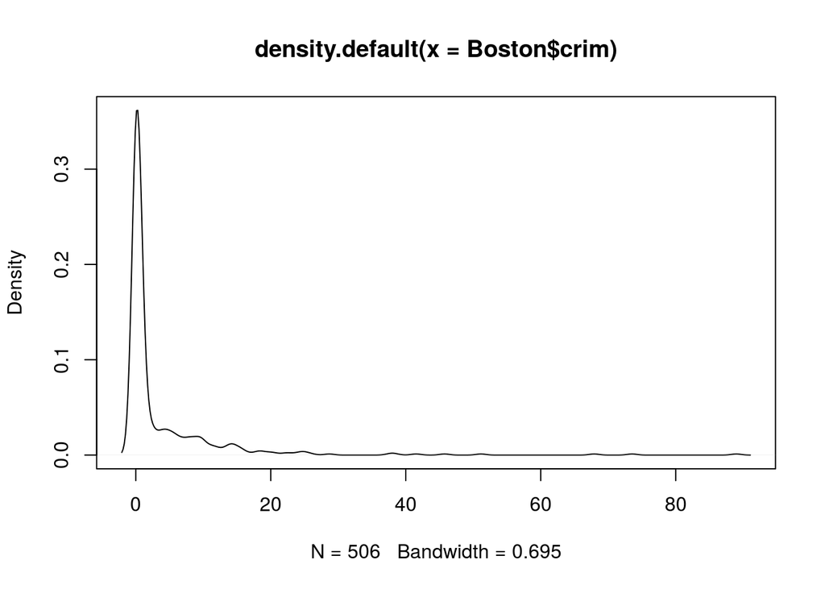

```r
plot(density(Boston$crim))
```

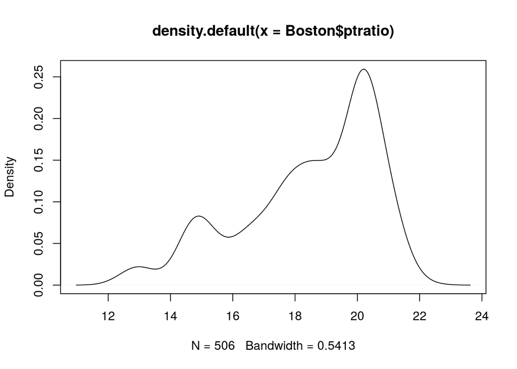

```r
plot(density(Boston$ptratio))
```

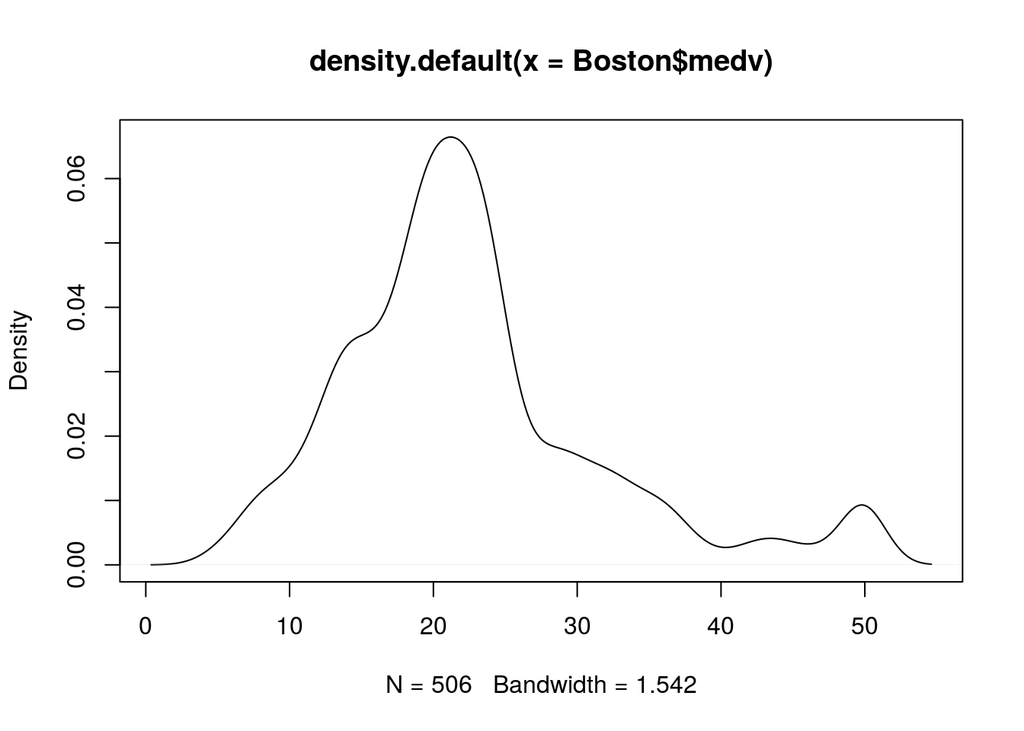

```r
plot(density(Boston$medv))
```

### Correlations, factoring, and dividing the data to test and training sets

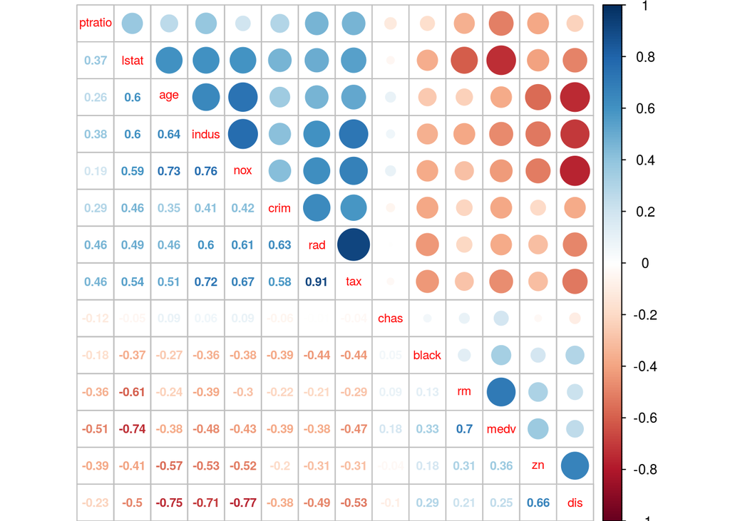

```r
#calculate the correlations and plot them
cor_matrix <- cor(Boston)
cor_matrix %>% round(digits=2) %>% corrplot.mixed(tl.cex = 0.7,number.cex=0.7,order="hclust",addrect=2)
```

From the correlation pairs plot we can see the relevant correlations between the variables. As one could expect industrial areas are related to nitrogen oxides concentration and negatively correlated with residential areas and employment centers. Crime is correlated among others with radial highways and industrial areas.

Next we standardize the data sets. The distributions are easier to see with standardized variables. Let’s divide the crime variable to a factor of size four: “low” to “high”. We divide the data to trainingsets and testsets with a share of 80%.

```r
boston_scaled <- scale(Boston)
summary(boston_scaled)
```

```
##       crim                 zn               indus
##  Min.   :-0.419367   Min.   :-0.48724   Min.   :-1.5563
##  1st Qu.:-0.410563   1st Qu.:-0.48724   1st Qu.:-0.8668
##  Median :-0.390280   Median :-0.48724   Median :-0.2109
##  Mean   : 0.000000   Mean   : 0.00000   Mean   : 0.0000
##  3rd Qu.: 0.007389   3rd Qu.: 0.04872   3rd Qu.: 1.0150
##  Max.   : 9.924110   Max.   : 3.80047   Max.   : 2.4202
##       chas              nox                rm               age
##  Min.   :-0.2723   Min.   :-1.4644   Min.   :-3.8764   Min.   :-2.3331
##  1st Qu.:-0.2723   1st Qu.:-0.9121   1st Qu.:-0.5681   1st Qu.:-0.8366
##  Median :-0.2723   Median :-0.1441   Median :-0.1084   Median : 0.3171
##  Mean   : 0.0000   Mean   : 0.0000   Mean   : 0.0000   Mean   : 0.0000
##  3rd Qu.:-0.2723   3rd Qu.: 0.5981   3rd Qu.: 0.4823   3rd Qu.: 0.9059
##  Max.   : 3.6648   Max.   : 2.7296   Max.   : 3.5515   Max.   : 1.1164
##       dis               rad               tax             ptratio
##  Min.   :-1.2658   Min.   :-0.9819   Min.   :-1.3127   Min.   :-2.7047
##  1st Qu.:-0.8049   1st Qu.:-0.6373   1st Qu.:-0.7668   1st Qu.:-0.4876
##  Median :-0.2790   Median :-0.5225   Median :-0.4642   Median : 0.2746
##  Mean   : 0.0000   Mean   : 0.0000   Mean   : 0.0000   Mean   : 0.0000
##  3rd Qu.: 0.6617   3rd Qu.: 1.6596   3rd Qu.: 1.5294   3rd Qu.: 0.8058
##  Max.   : 3.9566   Max.   : 1.6596   Max.   : 1.7964   Max.   : 1.6372
##      black             lstat              medv
##  Min.   :-3.9033   Min.   :-1.5296   Min.   :-1.9063
##  1st Qu.: 0.2049   1st Qu.:-0.7986   1st Qu.:-0.5989
##  Median : 0.3808   Median :-0.1811   Median :-0.1449
##  Mean   : 0.0000   Mean   : 0.0000   Mean   : 0.0000
##  3rd Qu.: 0.4332   3rd Qu.: 0.6024   3rd Qu.: 0.2683
##  Max.   : 0.4406   Max.   : 3.5453   Max.   : 2.9865
```

```r
boston_scaled <- as.data.frame(boston_scaled)
scaled_crim <- boston_scaled$crim
summary(scaled_crim)
```

```
##      Min.   1st Qu.    Median      Mean   3rd Qu.      Max.
## -0.419400 -0.410600 -0.390300  0.000000  0.007389  9.924000
```

```r
bins <- quantile(scaled_crim)
bins
```

```
##           0%          25%          50%          75%         100%
## -0.419366929 -0.410563278 -0.390280295  0.007389247  9.924109610
```

```r
crime <- cut(scaled_crim, breaks= bins, include.lowest = TRUE, labels = c("low", "med_low", "med_high", "high"))
crime
```

```
##   [1] low      low      low      low      low      low      med_low
##   [8] med_low  med_low  med_low  med_low  med_low  med_low  med_high
##  [15] med_high med_high med_high med_high med_high med_high med_high
##  [22] med_high med_high med_high med_high med_high med_high med_high
##  [29] med_high med_high med_high med_high med_high med_high med_high
##  [36] low      med_low  low      med_low  low      low      med_low
##  [43] med_low  med_low  med_low  med_low  med_low  med_low  med_low
##  [50] med_low  med_low  low      low      low      low      low
##  [57] low      low      med_low  med_low  med_low  med_low  med_low
##  [64] med_low  low      low      low      low      med_low  med_low
##  [71] med_low  med_low  med_low  med_low  low      med_low  med_low
##  [78] med_low  low      med_low  low      low      low      low
##  [85] low      low      low      low      low      low      low
##  [92] low      low      low      low      med_low  med_low  med_low
##  [99] low      low      med_low  med_low  med_low  med_low  med_low
```

[output cut: 59 more lines]

```r
boston_scaled <- dplyr::select(boston_scaled, -crim)
boston_scaled <- data.frame(boston_scaled, crime)

n <- nrow(boston_scaled)
n
```

```
## [1] 506
```

```r
index <- sample(n, size = n * 0.8)
index
```

[output not shown]

```r
trainingset <- boston_scaled[index,]
testset <- boston_scaled[-index,]

correct_classes <- testset$crime
testset <- dplyr::select(testset, -crime)
```

### The Linear Discriminant Analysis

Next we fit a lda model. We try to expain crime rate with other variables in the data. First level LDA does a good job on dividing the data. There are two main ‘groups’ high crime areas are vastly different from the rest groups. We can see that high crime is closely related to being close to radial highways (variable rad). This seems to be the dividing factor. From the testset and prediction table we can see that prediction of high crime is accurate but there is some dispersion in the med_high to low crime predictions. Our model seems to work quite adequately.

```r
lda.fit <- lda(crime ~ ., data = trainingset)
lda.fit
```

```
## Call:
## lda(crime ~ ., data = trainingset)
##
## Prior probabilities of groups:
##       low   med_low  med_high      high
## 0.2524752 0.2500000 0.2400990 0.2574257
##
## Group means:
##                  zn      indus         chas        nox          rm
## low       0.9525068 -0.9127345 -0.117932980 -0.8684019  0.47557895
## med_low  -0.1257562 -0.2889968 -0.116404306 -0.5811182 -0.16673268
## med_high -0.3970656  0.2505995  0.092968892  0.4136587  0.04772238
## high     -0.4872402  1.0170690 -0.007331936  1.0638468 -0.40331320
##                 age        dis        rad        tax      ptratio
## low      -0.8737998  0.8667261 -0.6823690 -0.7368011 -0.473971202
## med_low  -0.3166915  0.3666216 -0.5577344 -0.5128554  0.004532649
## med_high  0.4509657 -0.3740034 -0.4396053 -0.3005245 -0.228032494
## high      0.8074552 -0.8597663  1.6386213  1.5144083  0.781350740
##                black       lstat        medv
## low       0.37511063 -0.78749545  0.54402648
## med_low   0.31742135 -0.12795805 -0.03930794
## med_high  0.08682063  0.06644146  0.10673215
## high     -0.63269833  0.94036524 -0.70999759
##
## Coefficients of linear discriminants:
##                 LD1         LD2         LD3
## zn       0.07947735  0.69245841 -0.90311665
## indus    0.06807893 -0.33464662  0.27824440
## chas    -0.12223576  0.03903966  0.12692021
## nox      0.44020123 -0.76865786 -1.43743127
## rm      -0.09922324 -0.07255530 -0.21980122
## age      0.19999897 -0.39115692 -0.01038616
## dis     -0.01269843 -0.37527817  0.15197378
## rad      3.34127659  1.11317243  0.13369600
## tax      0.06433180 -0.16925781  0.28112745
## ptratio  0.13293317 -0.03472593 -0.21186952
## black   -0.10312693  0.02970985  0.10279804
## lstat    0.18059089 -0.17180757  0.28800817
## medv     0.18861349 -0.41362726 -0.27009962
##
## Proportion of trace:
##    LD1    LD2    LD3
## 0.9514 0.0361 0.0126
```

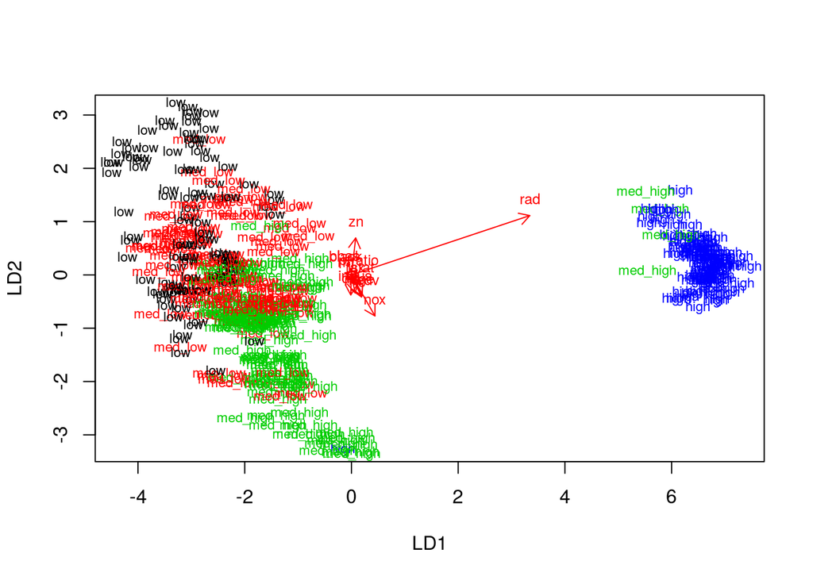

```r
lda.arrows <- function(x, myscale = 1, arrow_heads = 0.1, color = "red", tex = 0.75, choices = c(1,2)){
  heads <- coef(x)
  arrows(x0 = 0, y0 = 0,
         x1 = myscale * heads[,choices[1]],
         y1 = myscale * heads[,choices[2]], col=color, length = arrow_heads)
  text(myscale * heads[,choices], labels = row.names(heads),
       cex = tex, col=color, pos=3)
}

classes <- as.numeric(trainingset$crime)

plot(lda.fit, dimen =2, col = classes, pch = classes)
lda.arrows(lda.fit, myscale = 1)
```

```r
lda.pred <- predict(lda.fit, newdata = testset)

table(correct = correct_classes, predicted = lda.pred$class)
```

```
##           predicted
## correct    low med_low med_high high
##   low       15       9        1    0
##   med_low    6      15        4    0
##   med_high   1      11       15    2
##   high       0       0        0   23
```

### K-means clustering

Next we calculate the distance matrix to cluster the Boston data. As can be seen from pairs plot and ggpairs (this one is a bit messy), two centers seems to work quite well on the data. Number of centers is most appropriate when the total within sum of squares declines rapidly.

```r
library(MASS)
data('Boston')
dist_euclidian <- dist(Boston)
summary(dist_euclidian)
```

```
##    Min. 1st Qu.  Median    Mean 3rd Qu.    Max.
##   1.119  85.620 170.500 226.300 371.900 626.000
```

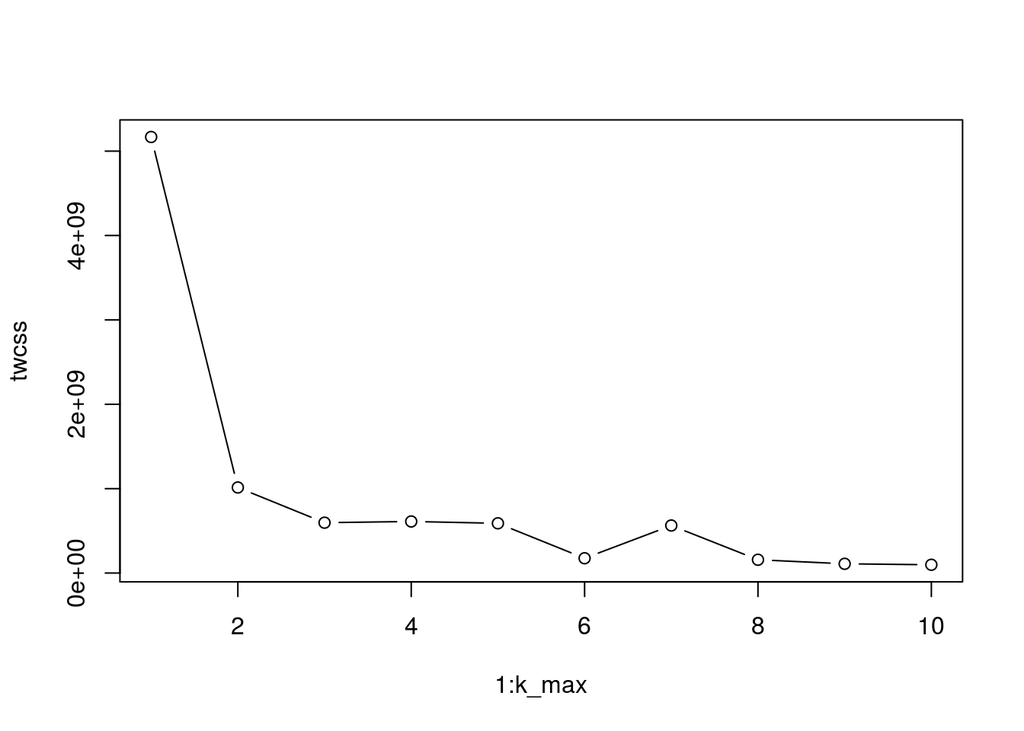

```r
k_max <- 10
twcss <- sapply(1:k_max, function(k){kmeans(dist_euclidian, k)$tot.withinss})

plot(1:k_max, twcss, type='b')
```

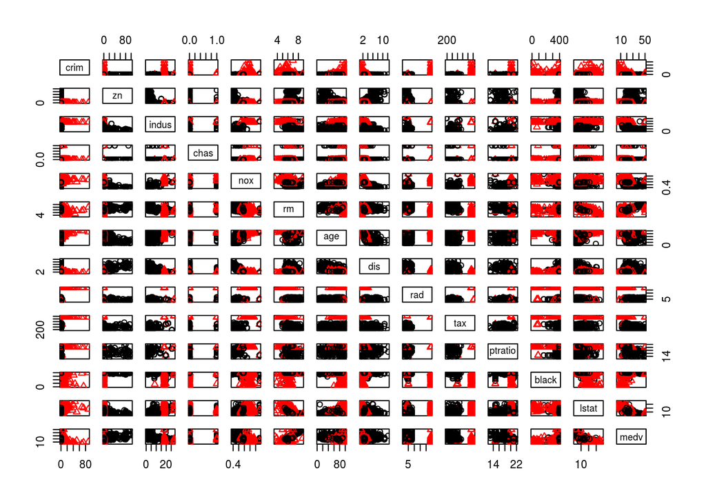

```r
km <- kmeans(dist_euclidian, centers=2)
pairs(Boston, col = c(km$cluster,alpha=0.2),pch=km$cluster)
```

```r
library(GGally)
data.frame(km$cluster)[,1]
```

[output not shown]

[output not shown]

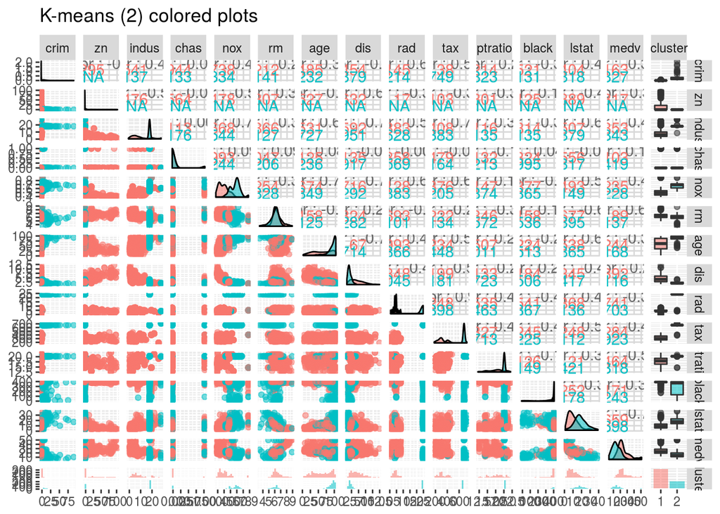

```r
Boston2 <- mutate(Boston, cluster = as.factor(data.frame(km$cluster)[,1]))
ggpairs(Boston2, mapping = aes(col = cluster, alpha = 0.3), lower = list(combo = wrap("facethist", bins = 20)), title ="K-means (2) colored plots")
```